## Header

- HW1
- Fall 2019, DSPA (HS650)
- Name: Chun-Hui Lin
- SID: 0084
- Umich E-mail: lchunhui@umich.edu
- I certify that the following paper represents my own independent work and conforms with the guidelines of academic honesty described in the UMich student handbook.

## Import Dataset

```r
library(rvest)
wiki_url <- read_html("http://wiki.socr.umich.edu/index.php/SOCR_Data_PD_BiomedBigMetadata")
html_nodes(wiki_url, "#content")
pd_data <- html_table(html_nodes(wiki_url,"table")[[1]])
```

## Problem 1.1 (Long-to-Wide Data format translation):

We demonstrated the wide-to-long conversion in lecture. Now, let’s explore long-to-wide. Load in the long-format SOCR Parkinson’s Disease data. and export it as wide format. For simplicity, just choose only 3 variables (avoiding case and time variables). Please note that there are several time observations for each subject. You need to transform the features according to the time variable. Try to use reshape function.

```r
pd_data_5 = pd_data[, c("Cases", "Sex", "Weight", "Age", "Time")]
pd_data_5_wide = reshape(pd_data_5, idvar = c("Cases", "Sex", "Weight", "Age"), timevar = 'Time', direction = 'wide')
pd_data_5_wide[1:5, ] #show part of the result
```

```
##    Cases Sex Weight Age
## 1      2   1     84  67
## 5      3   0     97  39
## 9      6   0     96  54
## 13     7   1     79  53
## 17     8   1     79  46
```

## Problem 1.2 (Data stratification):

Use the same SOCR Parkinson’s Disease data. and extract rows satisfying Time=0. Complete the following protocol in R:

- Extract the first 10 subjects

```r
pd_data_0 = subset(pd_data, pd_data$Time == 0)
pd_data_0[1:10, 1:3] #show part of the columns
```

```
##    Cases L_caudate_ComputeArea L_caudate_Volume
## 1      2                   597              767
## 5      3                   604              873
## 9      6                   580              797
## 13     7                   575              798
## 17     8                   578              837
## 21    10                   574              808
## 25    11                   604              829
## 29    12                   590              792
## 33    13                   549              798
## 37    14                   639              774
```

- Find the cases for which L_caudate_ComputeArea<600.

```r
pd_data_0[pd_data_0$L_caudate_ComputeArea < 600, 1:2][1:5, ] #show part of the result
```

```
##    Cases L_caudate_ComputeArea
## 1      2                   597
## 9      6                   580
## 13     7                   575
## 17     8                   578
## 21    10                   574
```

- Sort the subjects based on L_caudate_Volume in descending and ascending order.

```r
pd_data_0[order(pd_data_0$L_caudate_Volume), ][1:5, 1:3] #ascending; show part of the result
```

```
##     Cases L_caudate_ComputeArea L_caudate_Volume
## 761   471                   570              719
## 285   160                   551              727
## 413   264                   603              739
## 793   483                   625              740
## 717   455                   616              742
```

```r
pd_data_0[order(-pd_data_0$L_caudate_Volume), ][1:5, 1:3] #descending; show part of the result
```

```
##     Cases L_caudate_ComputeArea L_caudate_Volume
## 593   372                   652              890
## 257   136                   584              876
## 5       3                   604              873
## 405   259                   590              866
## 989   633                   613              860
```

- Generate frequency and probability tables for Age and Sex.

```r
table(pd_data_0$Age); table(pd_data_0$Sex) #frequency
```

```
##
## 31 38 39 40 42 43 44 45 46 47 48 49 50 51 52 53 54 55 56 57 58 59 60 61 62
##  1  1  3  2  1  3  8  3  8  1  5  6  4  9  3  7  9 14 12  7 18  7  8  8  8
## 63 64 65 66 67 68 69 70 71 72 73 74 75 76 77 78 79 80 82 83 85 87
## 11 10 11  9 11 10 14  7  2  6  4  7  1  5  3  3  5  2  2  1  1  1
```

```
##
##   0   1
## 117 165
```

```r
prop.table(table(pd_data_0$Age)); prop.table(table(pd_data_0$Sex)) #probability
```

```
##
##          31          38          39          40          42          43
## 0.003546099 0.003546099 0.010638298 0.007092199 0.003546099 0.010638298
##          44          45          46          47          48          49
## 0.028368794 0.010638298 0.028368794 0.003546099 0.017730496 0.021276596
##          50          51          52          53          54          55
## 0.014184397 0.031914894 0.010638298 0.024822695 0.031914894 0.049645390
##          56          57          58          59          60          61
## 0.042553191 0.024822695 0.063829787 0.024822695 0.028368794 0.028368794
##          62          63          64          65          66          67
## 0.028368794 0.039007092 0.035460993 0.039007092 0.031914894 0.039007092
##          68          69          70          71          72          73
## 0.035460993 0.049645390 0.024822695 0.007092199 0.021276596 0.014184397
##          74          75          76          77          78          79
## 0.024822695 0.003546099 0.017730496 0.010638298 0.010638298 0.017730496
##          80          82          83          85          87
## 0.007092199 0.007092199 0.003546099 0.003546099 0.003546099
```

```
##
##         0         1
## 0.4148936 0.5851064
```

- Compute the mean Age and the correlation between Age and Weight.

```r
mean(pd_data_0$Age) #mean
```

```
## [1] 60.6383
```

```r
cor(pd_data_0$Age, pd_data_0$Weight) #correlation
```

```
## [1] 0.1390514
```

- Plot Histogram and density of R_fusiform_gyrus_Volume and scatterplot L_fusiform_gyrus_Volume and R_fusiform_gyrus_Volume.

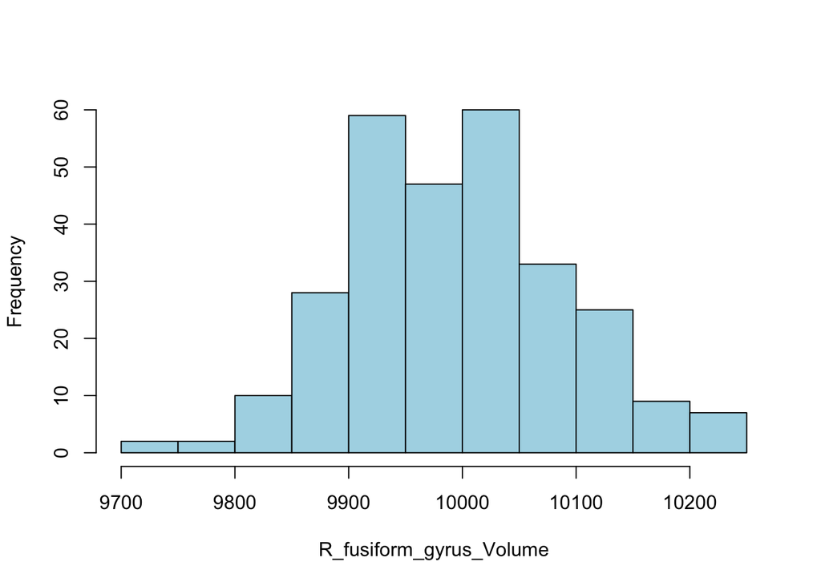

```r
hist(pd_data_0$R_fusiform_gyrus_Volume, main = NULL, xlab = "R_fusiform_gyrus_Volume",
     col = 'lightblue') #histogram
```

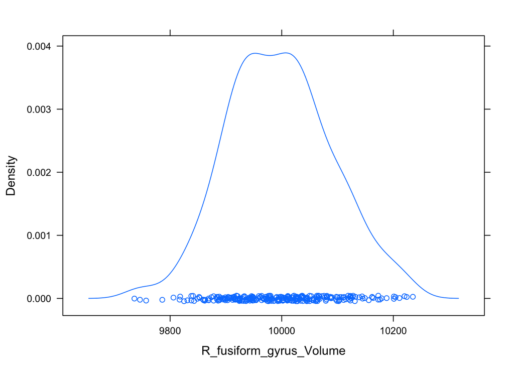

```r
densityplot(~pd_data_0$R_fusiform_gyrus_Volume, xlab = "R_fusiform_gyrus_Volume") #density
```

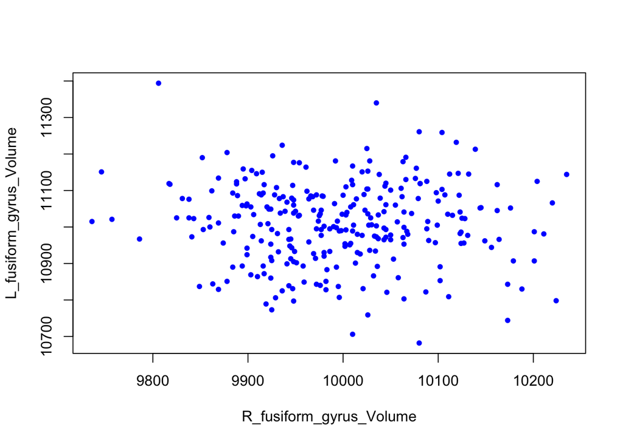

```r
plot(L_fusiform_gyrus_Volume ~ R_fusiform_gyrus_Volume, data = pd_data_0, pch = 20, col = 'blue') #scatterplot
```

## Problem 1.3 (Simulation)

Generate 1,000 standard normal variables and 1,200 student t distributed random variables with df=20. Generate a quantile-quantile (Q-Q) probability plot of the two samples. Then, compare it with qqnorm of student t simulation.

**The distribution of sampling student t data is much similar to the default normal data, comparing to the normal sampling one since the more dots at two tails are closer to qqline.**

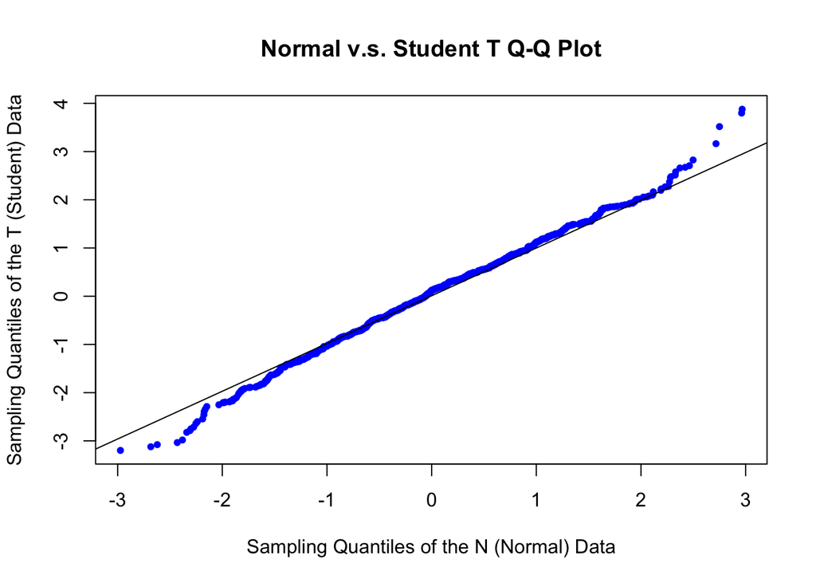

```r
set.seed(7)
nd = rnorm(1000, mean=0, sd=1); sd = rt(1200, 20)
qqplot(nd, sd, pch = 20, col = 'blue', xlab = 'Sampling Quantiles of the N (Normal) Data',
       ylab = 'Sampling Quantiles of the T (Student) Data', main = 'Normal v.s. Student T Q-Q Plot'); qqline(nd)
```

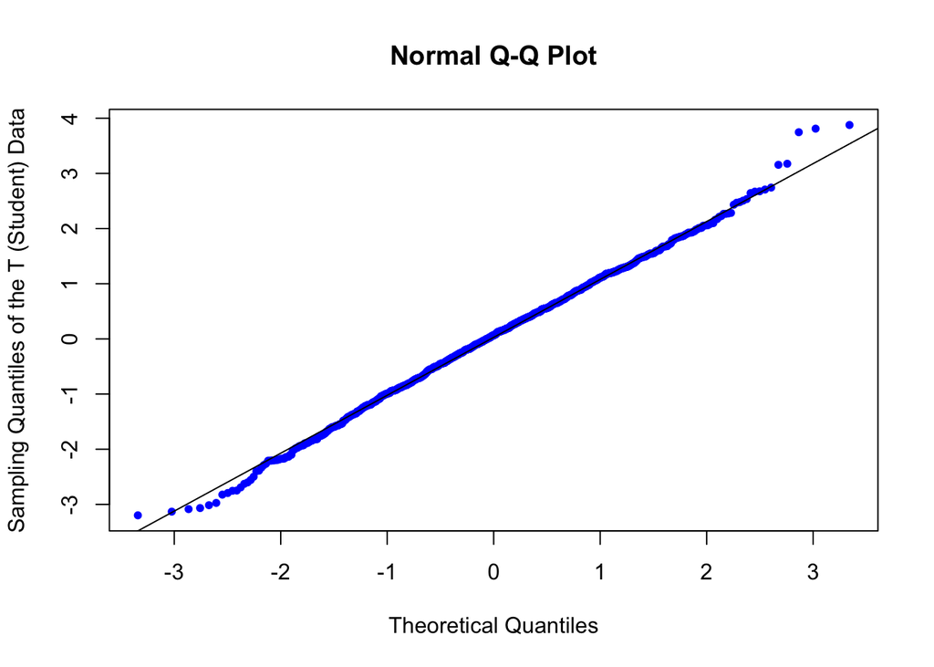

```r
qqnorm(sd, pch = 20, col = 'blue', ylab = 'Sampling Quantiles of the T (Student) Data'); qqline(sd)
```

## Problem 1.4 (Define an R SD function)

Generate a function that computes a sample standard deviation function and compare it against the sd function using the simulation data you generate in the last question.

```r
fun_sd = function(d){
  sqrt(sum((d - mean(d))^2)/(length(d) - 1))
}
c(sd(nd), sd(sd))
```

```
## [1] 0.9823217 1.0636471
```

```r
c(fun_sd(nd), fun_sd(sd))
```

```
## [1] 0.9823217 1.0636471
```